# Fase 5 - Selección clásica de características

```
        Este notebook reconstruye la lectura científica de la Fase 5 a partir de los artefactos ya ejecutados. No reajusta selectores ni recalcula métricas: interpreta rankings, estabilidad, permutaciones, redundancia, evidencias heredadas y datasets reducidos guardados previamente.

        La regla metodológica se mantiene intacta: cada selector se ajustó con `X_train, y_train`; validation y test solo reciben las columnas ya seleccionadas. Las tablas completas permanecen en `results/tables/05_feature_selection/` y aquí se muestran vistas compactas diseñadas para lectura humana.
```

```python
from pathlib import Path
import base64
import html
import os
import sys

import numpy as np
import pandas as pd
from pandas.errors import EmptyDataError
from IPython.display import HTML, Markdown, display

cwd = Path.cwd().resolve()
PROJECT_ROOT = cwd if (cwd / "src").exists() else cwd.parent
os.chdir(PROJECT_ROOT)
if str(PROJECT_ROOT / "src") not in sys.path:
    sys.path.insert(0, str(PROJECT_ROOT / "src"))

TABLE_DIR = PROJECT_ROOT / "results/tables/05_feature_selection"
FIGURE_DIR = PROJECT_ROOT / "results/figures/05_feature_selection"
REPORT_DIR = PROJECT_ROOT / "results/reports/05_feature_selection"
SELECTED_DIR = PROJECT_ROOT / "data/selected_features"

pd.set_option("display.max_columns", 12)
pd.set_option("display.width", 140)

TABLAS_REQUERIDAS = [
    "fs_input_dataset_summary.csv",
    "fs_inherited_warnings.csv",
    "fs_train_input_quality.csv",
    "fs_column_alignment_check.csv",
    "fs_method_registry.csv",
    "fs_method_configurations.csv",
    "fs_k_values_by_dataset.csv",
    "fs_sampling_plan.csv",
    "fs_sampling_representativeness.csv",
    "fs_baseline_summary.csv",
    "fs_all_rankings.csv",
    "fs_all_selected_features.csv",
    "fs_all_execution_times.csv",
    "fs_method_profiles.csv",
    "fs_jaccard_stability.csv",
    "fs_kuncheva_stability.csv",
    "fs_permutation_summary.csv",
    "fs_redundancy_vs_full.csv",
    "fs_selected_feature_evidence_map.csv",
    "fs_suspicious_selected_features.csv",
    "fs_figures_selected_for_report.csv",
    "fs_visual_audit.csv",
    "fs_reduced_datasets_log.csv",
    "fs_column_consistency_check.csv",
    "fs_phase6_input_recommendations.csv",
    "fs_phase5_final_checklist.csv",
    "fs_phase5_handoff_to_phase6.csv",
    "fs_phase5_open_issues.csv",
]


def cargar_csv(nombre):
    ruta = TABLE_DIR / nombre
    if not ruta.exists():
        raise FileNotFoundError(f"No existe {ruta}")
    try:
        return pd.read_csv(ruta)
    except EmptyDataError:
        return pd.DataFrame()


def _ruta_relativa_si_procede(valor):
    texto = str(valor)
    try:
        ruta = Path(texto)
        if ruta.is_absolute():
            return str(ruta.relative_to(PROJECT_ROOT))
    except Exception:
        pass
    return texto


def _truncar_texto(valor, max_caracteres=82):
    if pd.isna(valor):
        return ""
    texto = _ruta_relativa_si_procede(valor)
    texto = " ".join(str(texto).split())
    return texto if len(texto) <= max_caracteres else texto[: max_caracteres - 1] + "..."


def mostrar_tabla_compacta(tabla, titulo, columnas=None, ordenar_por=None, ascendente=True, max_filas=12, formato=None, max_columnas=8):
    vista = tabla.copy()
    if columnas is not None:
        vista = vista[[col for col in columnas if col in vista.columns]]
    elif len(vista.columns) > max_columnas:
        vista = vista[list(vista.columns[:max_columnas])]
    if ordenar_por is not None and ordenar_por in vista.columns:
        vista = vista.sort_values(ordenar_por, ascending=ascendente)
    if len(vista) > max_filas:
        vista = vista.iloc[:max_filas].copy()
    if formato:
        for columna, funcion in formato.items():
            if columna in vista.columns:
                vista[columna] = vista[columna].map(funcion)
    for columna in vista.select_dtypes(include="object").columns:
        vista[columna] = vista[columna].map(_truncar_texto)
    display(Markdown(f"**{titulo}**  \n{len(tabla)} filas completas en CSV; se muestra una vista compacta de {len(vista)} filas."))
    display(vista)
    return vista


def mostrar_figura(ruta_relativa, titulo=None):
    ruta = PROJECT_ROOT / ruta_relativa
    if not ruta.exists():
        display(Markdown(f"**Figura no encontrada:** `{ruta_relativa}`"))
        return
    if titulo:
        display(Markdown(f"**{titulo}**"))
    mime = "image/svg+xml" if ruta.suffix.lower() == ".svg" else "image/png"
    data = base64.b64encode(ruta.read_bytes()).decode("ascii")
    alt = html.escape(titulo or ruta.name)
    display(HTML(f'<img src="data:{mime};base64,{data}" alt="{alt}" style="width:920px; max-width:100%; height:auto;">'))


def porcentaje(valor):
    if pd.isna(valor):
        return ""
    return f"{100 * valor:.1f}%" if abs(valor) <= 1 else f"{valor:.1f}%"


def numero(valor):
    if pd.isna(valor):
        return ""
    return f"{valor:.3f}"


artefactos = {nombre: cargar_csv(nombre) for nombre in TABLAS_REQUERIDAS}
resumen_artefactos = pd.DataFrame(
    {
        "artefacto": nombre,
        "filas": len(tabla),
        "columnas": len(tabla.columns),
        "ruta": str((TABLE_DIR / nombre).relative_to(PROJECT_ROOT)),
    }
    for nombre, tabla in artefactos.items()
)
```

## Inventario de artefactos usados

```
        **Pregunta.** ¿La reconstrucción narrativa parte de artefactos existentes y trazables?

        **Criterio.** El notebook lee CSV y figuras ya generados por la fase. Si falta un artefacto requerido, la ejecución se detiene; si existe, se usa como evidencia, no como plantilla decorativa.
```

```python
mostrar_tabla_compacta(
    resumen_artefactos,
    "Artefactos tabulares cargados para la reconstrucción narrativa",
    columnas=["artefacto", "filas", "columnas", "ruta"],
    max_filas=10,
)
```

**Artefactos tabulares cargados para la reconstrucción narrativa**  
28 filas completas en CSV; se muestra una vista compacta de 10 filas.

|  | artefacto | filas | columnas | ruta |
| --- | --- | --- | --- | --- |
| 0 | fs_input_dataset_summary.csv | 5 | 7 | results/tables/05_feature_selection/fs_input_d... |
| 1 | fs_inherited_warnings.csv | 26 | 7 | results/tables/05_feature_selection/fs_inherit... |
| 2 | fs_train_input_quality.csv | 5 | 5 | results/tables/05_feature_selection/fs_train_i... |
| 3 | fs_column_alignment_check.csv | 5 | 5 | results/tables/05_feature_selection/fs_column_... |
| 4 | fs_method_registry.csv | 7 | 10 | results/tables/05_feature_selection/fs_method_... |
| 5 | fs_method_configurations.csv | 35 | 5 | results/tables/05_feature_selection/fs_method_... |
| 6 | fs_k_values_by_dataset.csv | 24 | 5 | results/tables/05_feature_selection/fs_k_value... |
| 7 | fs_sampling_plan.csv | 5 | 6 | results/tables/05_feature_selection/fs_samplin... |
| 8 | fs_sampling_representativeness.csv | 5 | 3 | results/tables/05_feature_selection/fs_samplin... |
| 9 | fs_baseline_summary.csv | 15 | 4 | results/tables/05_feature_selection/fs_baselin... |

|  | artefacto | filas | columnas | ruta |
| --- | --- | --- | --- | --- |
| 0 | fs_input_dataset_summary.csv | 5 | 7 | results/tables/05_feature_selection/fs_input_d... |
| 1 | fs_inherited_warnings.csv | 26 | 7 | results/tables/05_feature_selection/fs_inherit... |
| 2 | fs_train_input_quality.csv | 5 | 5 | results/tables/05_feature_selection/fs_train_i... |
| 3 | fs_column_alignment_check.csv | 5 | 5 | results/tables/05_feature_selection/fs_column_... |
| 4 | fs_method_registry.csv | 7 | 10 | results/tables/05_feature_selection/fs_method_... |
| 5 | fs_method_configurations.csv | 35 | 5 | results/tables/05_feature_selection/fs_method_... |
| 6 | fs_k_values_by_dataset.csv | 24 | 5 | results/tables/05_feature_selection/fs_k_value... |
| 7 | fs_sampling_plan.csv | 5 | 6 | results/tables/05_feature_selection/fs_samplin... |
| 8 | fs_sampling_representativeness.csv | 5 | 3 | results/tables/05_feature_selection/fs_samplin... |
| 9 | fs_baseline_summary.csv | 15 | 4 | results/tables/05_feature_selection/fs_baselin... |

```python
dataset_summary = artefactos["fs_input_dataset_summary.csv"]
method_registry = artefactos["fs_method_registry.csv"]
method_profiles = artefactos["fs_method_profiles.csv"]
execution_times = artefactos["fs_all_execution_times.csv"]
all_rankings = artefactos["fs_all_rankings.csv"]
jaccard = artefactos["fs_jaccard_stability.csv"]
kuncheva = artefactos["fs_kuncheva_stability.csv"]
permutation = artefactos["fs_permutation_summary.csv"]
redundancy = artefactos["fs_redundancy_vs_full.csv"]
evidence_map = artefactos["fs_selected_feature_evidence_map.csv"]
phase6_recommendations = artefactos["fs_phase6_input_recommendations.csv"]
figures = artefactos["fs_figures_selected_for_report.csv"]
visual_audit = artefactos["fs_visual_audit.csv"]

stability_summary = (
    jaccard.groupby(["dataset", "method"], as_index=False)
    .agg(mean_jaccard=("jaccard", "mean"), min_jaccard=("jaccard", "min"))
)
redundancy_summary = (
    redundancy.groupby(["dataset", "method"], as_index=False)
    .agg(mean_selected_corr=("selected_mean_abs_corr", "mean"), max_selected_corr=("selected_max_abs_corr", "max"))
)
method_dataset_profile = (
    execution_times.groupby(["dataset", "method"], as_index=False)
    .agg(mean_elapsed_seconds=("elapsed_seconds", "mean"), sample_applied=("sample_applied", "max"))
    .merge(stability_summary, on=["dataset", "method"], how="left")
    .merge(redundancy_summary, on=["dataset", "method"], how="left")
)

principal_phase6 = phase6_recommendations[phase6_recommendations["rol_fase6"].eq("principal_para_modelado")].copy()
principal_profile = principal_phase6.merge(
    method_dataset_profile,
    on=["dataset", "method"],
    how="left",
)

selection_frequency = (
    all_rankings[(all_rankings["selected"]) & (all_rankings["seed"].eq(42)) & (all_rankings["status"].eq("ok"))]
    .groupby(["dataset", "feature"], as_index=False)
    .agg(n_methods=("method", "nunique"), best_rank=("rank", "min"))
    .sort_values(["dataset", "n_methods", "best_rank"], ascending=[True, False, True])
)

top_features_by_dataset = (
    selection_frequency[selection_frequency.groupby("dataset").cumcount() < 6]
    .reset_index(drop=True)
)

dataset_method_reading = principal_profile.copy()
mean_jaccard_numeric = pd.to_numeric(dataset_method_reading["mean_jaccard"], errors="coerce").fillna(0)
mean_selected_corr_numeric = pd.to_numeric(dataset_method_reading["mean_selected_corr"], errors="coerce").fillna(0)
dataset_method_reading["lectura"] = np.where(
    mean_jaccard_numeric >= 0.85,
    "estable entre semillas",
    "sensible a semilla o alternativas equivalentes",
)
dataset_method_reading["cautela_redundancia"] = np.where(
    mean_selected_corr_numeric >= 0.5,
    "vigilar redundancia",
    "redundancia contenida",
)
```

## 5.1 Splits y advertencias heredadas

```
        **Pregunta.** ¿Qué problemas y cautelas entran a la selección clásica desde las fases anteriores?

        **Artefactos usados.** `fs_input_dataset_summary.csv`, `fs_inherited_warnings.csv`, handoff de Fase 4 y splits de `data/splits/`.

        **Criterio metodológico.** Fase 5 solo continúa con datasets aceptados en Fase 4. `olive_oil` se trata como dos problemas distintos (`olive_oil_3class` y `olive_oil_9class`) y no como un dataset ambiguo.
```

```python
mostrar_tabla_compacta(
    dataset_summary,
    "Tamaño y dimensionalidad de los datasets que entran a selección",
    columnas=["dataset", "train_rows", "validation_rows", "test_rows", "raw_features", "processed_features", "classes"],
    max_filas=8,
)

inherited = artefactos["fs_inherited_warnings.csv"]
if len(inherited):
    columnas_warning = [col for col in ["dataset", "tipo", "gravedad", "riesgo", "accion", "evidencia"] if col in inherited.columns]
    mostrar_tabla_compacta(inherited, "Cautelas heredadas relevantes", columnas=columnas_warning, max_filas=12)
else:
    display(Markdown("No hay advertencias heredadas registradas en `fs_inherited_warnings.csv`."))
```

**Tamaño y dimensionalidad de los datasets que entran a selección**  
5 filas completas en CSV; se muestra una vista compacta de 5 filas.

|  | dataset | train_rows | validation_rows | test_rows | raw_features | processed_features | classes |
| --- | --- | --- | --- | --- | --- | --- | --- |
| 0 | breast_cancer_wisconsin | 397 | 86 | 86 | 30 | 30 | 2 |
| 1 | customer_churn | 308582 | 66125 | 66125 | 10 | 15 | 2 |
| 2 | madelon | 1400 | 300 | 300 | 500 | 500 | 2 |
| 3 | olive_oil_3class | 400 | 86 | 86 | 8 | 8 | 3 |
| 4 | olive_oil_9class | 400 | 86 | 86 | 8 | 8 | 9 |

**Cautelas heredadas relevantes**  
26 filas completas en CSV; se muestra una vista compacta de 12 filas.

|  | dataset | tipo | gravedad | riesgo | accion | evidencia |
| --- | --- | --- | --- | --- | --- | --- |
| 0 | madelon | heredado_fase3 | medio | ratio features/muestras elevado | split estratificado y control de dimensionalidad | postprocessed_dimensionality_summary.csv |
| 1 | breast_cancer_wisconsin | heredado_fase3 | bajo | redundancia alta | vigilar selección redundante | postprocessed_high_correlation_pairs.csv |
| 2 | madelon | heredado_fase3 | bajo | redundancia alta | vigilar selección redundante | postprocessed_high_correlation_pairs.csv |
| 3 | customer_churn | heredado_fase3 | medio | 3 features categóricas pendientes de codificación | codificar dentro del pipeline ajustado solo co... | postprocessed_categorical_features_pending.csv |
| 4 | olive_oil_3class | heredado_fase3 | medio | target multiclase | estratificar por clase y revisar clases minori... | postprocessed_dimensionality_summary.csv |
| 5 | olive_oil_3class | heredado_fase3 | medio | desbalance de target | usar split estratificado | postprocessed_target_integrity.csv |
| 6 | olive_oil_9class | heredado_fase3 | medio | target multiclase | estratificar por clase y revisar clases minori... | postprocessed_dimensionality_summary.csv |
| 7 | olive_oil_9class | heredado_fase3 | medio | desbalance de target | usar split estratificado | postprocessed_target_integrity.csv |
| 8 | breast_cancer_wisconsin | drift | medio | 8 variables con drift marginal | vigilar en selección y modelado; no usar el ra... | split_variable_distribution_tests.csv |
| 9 | olive_oil_3class | drift | medio | 1 variables con drift marginal | vigilar en selección y modelado; no usar el ra... | split_variable_distribution_tests.csv |
| 10 | olive_oil_9class | drift | medio | 1 variables con drift marginal | vigilar en selección y modelado; no usar el ra... | split_variable_distribution_tests.csv |
| 11 | madelon | heredado_fase3 | medio | ratio features/muestras elevado | split estratificado y control de dimensionalidad | postprocessed_dimensionality_summary.csv |

**Lectura.** `customer_churn` exige atención por codificación ajustada solo con train; `madelon` llega con alta dimensionalidad; `breast_cancer_wisconsin` y las dos formulaciones de Olive Oil arrastran cautelas de drift o redundancia. Estas advertencias no bloquean la fase, pero condicionan cómo interpretar estabilidad, redundancia y utilidad para Fase 6.

## 5.2 Protocolo y familias de métodos

```
        **Pregunta.** ¿Qué pregunta responde cada familia de selección y qué limitación introduce?

        **Criterio metodológico.** Se comparan filtros, filtros supervisados, relevancia-redundancia, regularización y métodos embedded. Ninguno usa validation/test para decidir columnas.
```

```python
familias = method_registry.copy()
familias["lectura_metodológica"] = familias["family"].map(
    {
        "filtros": "ordena variables por una propiedad simple; es barato, pero no usa el target",
        "filtros supervisados": "mide asociación marginal con el target; puede ignorar interacciones y redundancia",
        "relevancia-redundancia": "busca señal evitando variables repetidas; depende de la aproximación mRMR usada",
        "regularizacion": "favorece subconjuntos parsimoniosos mediante penalización; sensible a escalado y correlación",
        "embedded": "usa un modelo para estimar importancia; puede ser estable o costoso según dataset",
    }
)
mostrar_tabla_compacta(
    familias,
    "Familias, contrato train-only y limitaciones principales",
    columnas=["method", "family", "uses_target", "has_randomness", "requires_sample_when_large", "expected_cost", "fit_scope", "lectura_metodológica"],
    max_filas=10,
)
```

**Familias, contrato train-only y limitaciones principales**  
7 filas completas en CSV; se muestra una vista compacta de 7 filas.

|  | method | family | uses_target | has_randomness | requires_sample_when_large | expected_cost | fit_scope | lectura_metodológica |
| --- | --- | --- | --- | --- | --- | --- | --- | --- |
| 0 | variance | filtros | False | False | False | bajo | X_train_y_train_only | ordena variables por una propiedad simple; es ... |
| 1 | f_classif | filtros supervisados | True | False | False | bajo | X_train_y_train_only | mide asociación marginal con el target; puede ... |
| 2 | mutual_info | filtros supervisados | True | True | False | medio | X_train_y_train_only | mide asociación marginal con el target; puede ... |
| 3 | mrmr_approx | relevancia-redundancia | True | True | True | medio | X_train_y_train_only | busca señal evitando variables repetidas; depe... |
| 4 | l1_logistic | regularizacion | True | True | True | medio | X_train_y_train_only | favorece subconjuntos parsimoniosos mediante p... |
| 5 | random_forest | embedded | True | True | True | medio | X_train_y_train_only | usa un modelo para estimar importancia; puede ... |
| 6 | linear_svm | embedded | True | True | True | medio | X_train_y_train_only | usa un modelo para estimar importancia; puede ... |

|  | method | family | uses_target | has_randomness | requires_sample_when_large | expected_cost | fit_scope | lectura_metodológica |
| --- | --- | --- | --- | --- | --- | --- | --- | --- |
| 0 | variance | filtros | False | False | False | bajo | X_train_y_train_only | ordena variables por una propiedad simple; es ... |
| 1 | f_classif | filtros supervisados | True | False | False | bajo | X_train_y_train_only | mide asociación marginal con el target; puede ... |
| 2 | mutual_info | filtros supervisados | True | True | False | medio | X_train_y_train_only | mide asociación marginal con el target; puede ... |
| 3 | mrmr_approx | relevancia-redundancia | True | True | True | medio | X_train_y_train_only | busca señal evitando variables repetidas; depe... |
| 4 | l1_logistic | regularizacion | True | True | True | medio | X_train_y_train_only | favorece subconjuntos parsimoniosos mediante p... |
| 5 | random_forest | embedded | True | True | True | medio | X_train_y_train_only | usa un modelo para estimar importancia; puede ... |
| 6 | linear_svm | embedded | True | True | True | medio | X_train_y_train_only | usa un modelo para estimar importancia; puede ... |

**Decisión.** La comparación no busca declarar un selector universalmente mejor. Busca una base clásica defendible para contrastar en Fase 6: métodos baratos para referencia, métodos supervisados para señal marginal, métodos multivariantes para redundancia y métodos embedded para importancias dependientes de modelo.

## 5.3 Preparación de matrices y contrato train-only

```
        **Pregunta.** ¿Las matrices que reciben los selectores cumplen el contrato de no fuga?

        **Artefactos usados.** `fs_train_input_quality.csv`, `fs_column_alignment_check.csv`, `fs_suspicious_selected_features.csv`.

        **Criterio metodológico.** El preprocesado que afecta a variables predictoras se ajusta en train y se aplica a validation/test. Las columnas prohibidas no entran en X.
```

```python
quality = artefactos["fs_train_input_quality.csv"]
alignment = artefactos["fs_column_alignment_check.csv"]
suspicious = artefactos["fs_suspicious_selected_features.csv"]
mostrar_tabla_compacta(quality, "Calidad de entrada por dataset", max_filas=8)
mostrar_tabla_compacta(alignment, "Alineación train/validation/test y ausencia de target en X", max_filas=8)
display(Markdown(f"**Variables sospechosas seleccionadas:** {len(suspicious)} registros."))
```

**Calidad de entrada por dataset**  
5 filas completas en CSV; se muestra una vista compacta de 5 filas.

|  | dataset | n_missing_train | n_infinite_train | duplicated_feature_names | status |
| --- | --- | --- | --- | --- | --- |
| 0 | breast_cancer_wisconsin | 0 | 0 | 0 | ok |
| 1 | customer_churn | 0 | 0 | 0 | ok |
| 2 | madelon | 0 | 0 | 0 | ok |
| 3 | olive_oil_3class | 0 | 0 | 0 | ok |
| 4 | olive_oil_9class | 0 | 0 | 0 | ok |

**Alineación train/validation/test y ausencia de target en X**  
5 filas completas en CSV; se muestra una vista compacta de 5 filas.

|  | dataset | same_columns_train_validation_test | x_y_train_aligned | target_not_in_features | status |
| --- | --- | --- | --- | --- | --- |
| 0 | breast_cancer_wisconsin | True | True | True | ok |
| 1 | customer_churn | True | True | True | ok |
| 2 | madelon | True | True | True | ok |
| 3 | olive_oil_3class | True | True | True | ok |
| 4 | olive_oil_9class | True | True | True | ok |

**Variables sospechosas seleccionadas:** 0 registros.

**Interpretación.** La evidencia apunta a matrices alineadas y sin selección de columnas sospechosas. La ausencia de sospechosas no garantiza ausencia absoluta de proxies semánticos; por eso el riesgo residual se mantiene documentado para modelado.

## 5.4 Configuración real de métodos

```
        **Pregunta.** ¿Qué métodos se ejecutan completos y cuáles requieren control de coste?

        **Criterio metodológico.** Los métodos baratos se ejecutan sobre train completo. En datasets grandes, los métodos costosos pueden usar muestra estratificada documentada; sus tiempos no se comparan como si fueran ejecución completa.
```

```python
config = artefactos["fs_method_configurations.csv"]
config_resumen = config.pivot_table(index="dataset", columns="decision", values="method", aggfunc="count", fill_value=0).reset_index()
mostrar_tabla_compacta(config_resumen, "Plan de ejecución por dataset", max_filas=8)
mostrar_tabla_compacta(
    method_dataset_profile,
    "Coste, muestreo y estabilidad por dataset-método",
    columnas=["dataset", "method", "mean_elapsed_seconds", "sample_applied", "mean_jaccard", "mean_selected_corr"],
    ordenar_por="mean_elapsed_seconds",
    ascendente=False,
    max_filas=12,
    formato={"mean_elapsed_seconds": numero, "mean_jaccard": numero, "mean_selected_corr": numero},
)
```

**Plan de ejecución por dataset**  
5 filas completas en CSV; se muestra una vista compacta de 5 filas.

| decision | dataset | execute_full_train | execute_with_stratified_sample |
| --- | --- | --- | --- |
| 0 | breast_cancer_wisconsin | 7 | 0 |
| 1 | customer_churn | 2 | 5 |
| 2 | madelon | 7 | 0 |
| 3 | olive_oil_3class | 7 | 0 |
| 4 | olive_oil_9class | 7 | 0 |

**Coste, muestreo y estabilidad por dataset-método**  
35 filas completas en CSV; se muestra una vista compacta de 12 filas.

|  | dataset | method | mean_elapsed_seconds | sample_applied | mean_jaccard | mean_selected_corr |
| --- | --- | --- | --- | --- | --- | --- |
| 17 | madelon | mrmr_approx | 1.805 | False | 0.111 | 0.017 |
| 15 | madelon | l1_logistic | 1.284 | False | 1.000 | 0.041 |
| 18 | madelon | mutual_info | 0.988 | False | 0.127 | 0.053 |
| 12 | customer_churn | random_forest | 0.817 | True | 1.000 | 0.089 |
| 5 | breast_cancer_wisconsin | random_forest | 0.666 | False | 0.852 | 0.681 |
| 33 | olive_oil_9class | random_forest | 0.626 | False | 0.926 | 0.461 |
| 26 | olive_oil_3class | random_forest | 0.617 | False | 1.000 | 0.448 |
| 19 | madelon | random_forest | 0.284 | False | 0.681 | 0.306 |
| 1 | breast_cancer_wisconsin | l1_logistic | 0.112 | False | 1.000 | 0.488 |
| 10 | customer_churn | mrmr_approx | 0.103 | True | 0.756 | 0.075 |
| 11 | customer_churn | mutual_info | 0.101 | True | 0.742 | 0.096 |
| 16 | madelon | linear_svm | 0.038 | False | 1.000 | 0.148 |

|  | dataset | method | mean_elapsed_seconds | sample_applied | mean_jaccard | mean_selected_corr |
| --- | --- | --- | --- | --- | --- | --- |
| 17 | madelon | mrmr_approx | 1.805 | False | 0.111 | 0.017 |
| 15 | madelon | l1_logistic | 1.284 | False | 1.000 | 0.041 |
| 18 | madelon | mutual_info | 0.988 | False | 0.127 | 0.053 |
| 12 | customer_churn | random_forest | 0.817 | True | 1.000 | 0.089 |
| 5 | breast_cancer_wisconsin | random_forest | 0.666 | False | 0.852 | 0.681 |
| 33 | olive_oil_9class | random_forest | 0.626 | False | 0.926 | 0.461 |
| 26 | olive_oil_3class | random_forest | 0.617 | False | 1.000 | 0.448 |
| 19 | madelon | random_forest | 0.284 | False | 0.681 | 0.306 |
| 1 | breast_cancer_wisconsin | l1_logistic | 0.112 | False | 1.000 | 0.488 |
| 10 | customer_churn | mrmr_approx | 0.103 | True | 0.756 | 0.075 |
| 11 | customer_churn | mutual_info | 0.101 | True | 0.742 | 0.096 |
| 16 | madelon | linear_svm | 0.038 | False | 1.000 | 0.148 |

**Decisión.** La salida de métodos fallidos se conserva como evidencia negativa. En la ejecución actual no hay métodos fallidos ni warnings de método, por lo que la comparación puede apoyarse en todos los selectores registrados.

## 5.5 Valores de k

```
        **Pregunta.** ¿Las reducciones de dimensionalidad son razonables para cada dataset?

        **Criterio metodológico.** Los valores de k se acotan por número de variables disponibles: no se exige el mismo k a Olive Oil que a Madelon. La figura se muestra aquí porque explica el diseño experimental, no al final como galería.
```

**Valores de k por dataset**  
5 filas completas en CSV; se muestra una vista compacta de 5 filas.

|  | dataset | n_features | k_values | max_reduction_pct |
| --- | --- | --- | --- | --- |
| 0 | breast_cancer_wisconsin | 30 | 3, 5, 10, 15, 20, 30 | 90.0% |
| 1 | customer_churn | 15 | 1, 4, 5, 10, 15 | 93.3% |
| 2 | madelon | 500 | 5, 10, 15, 20, 22, 30, 50 | 99.0% |
| 3 | olive_oil_3class | 8 | 3, 5, 8 | 62.5% |
| 4 | olive_oil_9class | 8 | 3, 5, 8 | 62.5% |

**Plan de k y reducción dimensional**

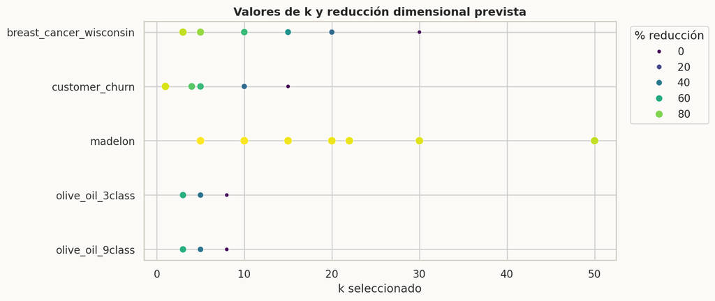

```python
k_values = artefactos["fs_k_values_by_dataset.csv"]
k_compacto = (
    k_values.groupby("dataset", as_index=False)
    .agg(n_features=("n_features", "max"), k_values=("k", lambda serie: ", ".join(map(str, sorted(serie.unique())))), max_reduction_pct=("reduction_pct", "max"))
)
mostrar_tabla_compacta(k_compacto, "Valores de k por dataset", max_filas=8, formato={"max_reduction_pct": lambda valor: f"{valor:.1f}%"})
mostrar_figura("results/figures/05_feature_selection/protocol/fs_k_reduction_plan.png", "Plan de k y reducción dimensional")
```

**Implicación para Fase 6.** Los subconjuntos con k pequeño permiten comparar modelos bajo reducción agresiva; los k cercanos a la dimensionalidad original sirven como control de sensibilidad.

## 5.6 Muestreo para coste computacional

```
        **Pregunta.** ¿El control de coste altera de forma visible la distribución del target?

        **Criterio metodológico.** El muestreo solo se usa para métodos costosos y se registra. La representatividad se evalúa con diferencia máxima de proporciones del target.
```

```python
sampling = artefactos["fs_sampling_plan.csv"].merge(artefactos["fs_sampling_representativeness.csv"], on="dataset", how="left")
mostrar_tabla_compacta(
    sampling,
    "Muestreo y representatividad por dataset",
    columnas=["dataset", "sample_applied", "sample_size", "train_size", "max_abs_target_prop_diff", "justification"],
    max_filas=8,
    formato={"max_abs_target_prop_diff": porcentaje},
)
```

**Muestreo y representatividad por dataset**  
5 filas completas en CSV; se muestra una vista compacta de 5 filas.

|  | dataset | sample_applied | sample_size | train_size | max_abs_target_prop_diff | justification |
| --- | --- | --- | --- | --- | --- | --- |
| 0 | breast_cancer_wisconsin | False | 397 | 397 | 0.0% | dataset completo viable |
| 1 | customer_churn | True | 5000 | 308582 | 0.0% | muestra estratificada para métodos costosos |
| 2 | madelon | False | 1400 | 1400 | 0.0% | dataset completo viable |
| 3 | olive_oil_3class | False | 400 | 400 | 0.0% | dataset completo viable |
| 4 | olive_oil_9class | False | 400 | 400 | 0.0% | dataset completo viable |

|  | dataset | sample_applied | sample_size | train_size | max_abs_target_prop_diff | justification |
| --- | --- | --- | --- | --- | --- | --- |
| 0 | breast_cancer_wisconsin | False | 397 | 397 | 0.0% | dataset completo viable |
| 1 | customer_churn | True | 5000 | 308582 | 0.0% | muestra estratificada para métodos costosos |
| 2 | madelon | False | 1400 | 1400 | 0.0% | dataset completo viable |
| 3 | olive_oil_3class | False | 400 | 400 | 0.0% | dataset completo viable |
| 4 | olive_oil_9class | False | 400 | 400 | 0.0% | dataset completo viable |

**Interpretación.** `customer_churn` es el único dataset con muestra estratificada por tamaño. La diferencia máxima de proporciones registrada es muy baja, pero los tiempos de sus métodos muestreados deben leerse como tiempos sobre muestra, no sobre train completo.

## 5.7 y 5.8 Selección baseline y selección clásica completa

```
        **Pregunta.** ¿Qué métodos producen señal recurrente y qué variables aparecen repetidamente por dataset?

        **Criterio metodológico.** La baseline rápida se interpreta como referencia mínima. La selección completa incorpora métodos con distintas hipótesis para evitar que una sola familia dicte la narrativa.
```

```python
baseline = artefactos["fs_baseline_summary.csv"]
mostrar_tabla_compacta(
    baseline,
    "Resumen de baseline rápida",
    columnas=["dataset", "method", "mean_elapsed_seconds", "n_selected_rows"],
    ordenar_por="dataset",
    max_filas=15,
    formato={"mean_elapsed_seconds": numero},
)
mostrar_tabla_compacta(
    top_features_by_dataset,
    "Variables más recurrentes por dataset en selección completa",
    columnas=["dataset", "feature", "n_methods", "best_rank"],
    max_filas=20,
)
```

**Resumen de baseline rápida**  
15 filas completas en CSV; se muestra una vista compacta de 15 filas.

|  | dataset | method | mean_elapsed_seconds | n_selected_rows |
| --- | --- | --- | --- | --- |
| 0 | breast_cancer_wisconsin | f_classif | 0.000 | 249 |
| 1 | breast_cancer_wisconsin | mutual_info | 0.025 | 249 |
| 2 | breast_cancer_wisconsin | variance | 0.000 | 249 |
| 3 | customer_churn | f_classif | 0.029 | 105 |
| 4 | customer_churn | mutual_info | 0.101 | 105 |
| 5 | customer_churn | variance | 0.032 | 105 |
| 6 | madelon | f_classif | 0.002 | 456 |
| 7 | madelon | mutual_info | 0.988 | 456 |
| 8 | madelon | variance | 0.002 | 456 |
| 9 | olive_oil_3class | f_classif | 0.000 | 48 |
| 10 | olive_oil_3class | mutual_info | 0.009 | 48 |
| 11 | olive_oil_3class | variance | 0.000 | 48 |
| 12 | olive_oil_9class | f_classif | 0.001 | 48 |
| 13 | olive_oil_9class | mutual_info | 0.017 | 48 |
| 14 | olive_oil_9class | variance | 0.000 | 48 |

**Variables más recurrentes por dataset en selección completa**  
30 filas completas en CSV; se muestra una vista compacta de 20 filas.

|  | dataset | feature | n_methods | best_rank |
| --- | --- | --- | --- | --- |
| 0 | breast_cancer_wisconsin | area_worst | 7 | 1 |
| 1 | breast_cancer_wisconsin | compactness_worst | 7 | 1 |
| 2 | breast_cancer_wisconsin | concave_points_worst | 7 | 1 |
| 3 | breast_cancer_wisconsin | perimeter_worst | 7 | 1 |
| 4 | breast_cancer_wisconsin | radius_se | 7 | 1 |
| 5 | breast_cancer_wisconsin | radius_worst | 7 | 1 |
| 6 | customer_churn | contract_length_Monthly | 7 | 1 |
| 7 | customer_churn | support_calls | 7 | 1 |
| 8 | customer_churn | tenure | 7 | 1 |
| 9 | customer_churn | total_spend | 7 | 2 |
| 10 | customer_churn | age | 7 | 3 |
| 11 | customer_churn | contract_length_Annual | 7 | 3 |
| 12 | madelon | feat_241 | 6 | 1 |
| 13 | madelon | feat_475 | 5 | 1 |
| 14 | madelon | feat_44 | 5 | 2 |
| 15 | madelon | feat_128 | 5 | 4 |
| 16 | madelon | feat_153 | 5 | 4 |
| 17 | madelon | feat_48 | 4 | 2 |
| 18 | olive_oil_3class | other | 7 | 1 |
| 19 | olive_oil_3class | stearic | 7 | 1 |

|  | dataset | feature | n_methods | best_rank |
| --- | --- | --- | --- | --- |
| 0 | breast_cancer_wisconsin | area_worst | 7 | 1 |
| 1 | breast_cancer_wisconsin | compactness_worst | 7 | 1 |
| 2 | breast_cancer_wisconsin | concave_points_worst | 7 | 1 |
| 3 | breast_cancer_wisconsin | perimeter_worst | 7 | 1 |
| 4 | breast_cancer_wisconsin | radius_se | 7 | 1 |
| 5 | breast_cancer_wisconsin | radius_worst | 7 | 1 |
| 6 | customer_churn | contract_length_Monthly | 7 | 1 |
| 7 | customer_churn | support_calls | 7 | 1 |
| 8 | customer_churn | tenure | 7 | 1 |
| 9 | customer_churn | total_spend | 7 | 2 |
| 10 | customer_churn | age | 7 | 3 |
| 11 | customer_churn | contract_length_Annual | 7 | 3 |
| 12 | madelon | feat_241 | 6 | 1 |
| 13 | madelon | feat_475 | 5 | 1 |
| 14 | madelon | feat_44 | 5 | 2 |
| 15 | madelon | feat_128 | 5 | 4 |
| 16 | madelon | feat_153 | 5 | 4 |
| 17 | madelon | feat_48 | 4 | 2 |
| 18 | olive_oil_3class | other | 7 | 1 |
| 19 | olive_oil_3class | stearic | 7 | 1 |

**Lectura por dataset.** En Breast Cancer predominan variables morfológicas correlacionadas; en `customer_churn` aparecen variables operativas de uso, soporte y contrato; en Madelon la selección debe leerse con cautela por alta dimensionalidad y ruido; en Olive Oil las variables químicas son pocas y tienden a repetirse entre métodos, por lo que la comparación relevante se desplaza hacia estabilidad y formulación del target.

**Variables recurrentes en breast_cancer_wisconsin**

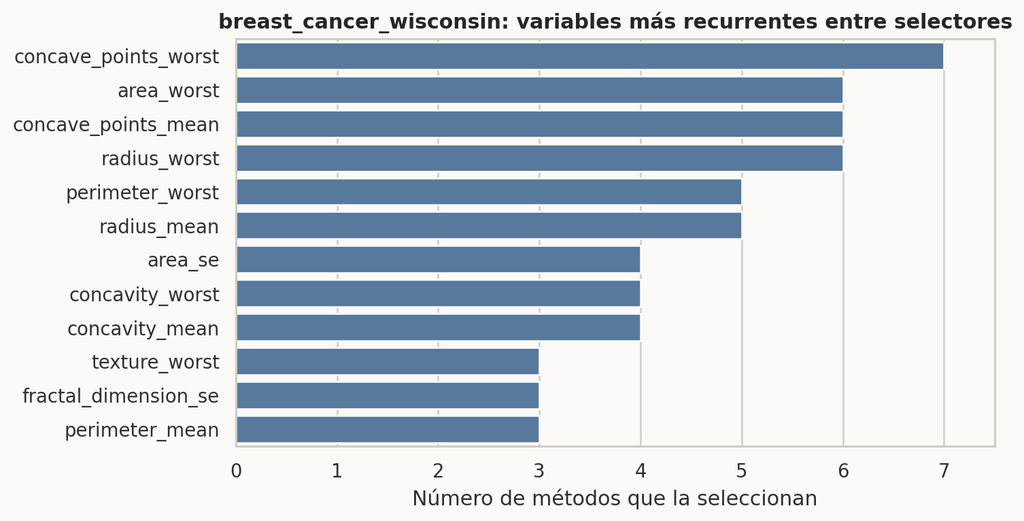

**Variables recurrentes en customer_churn**

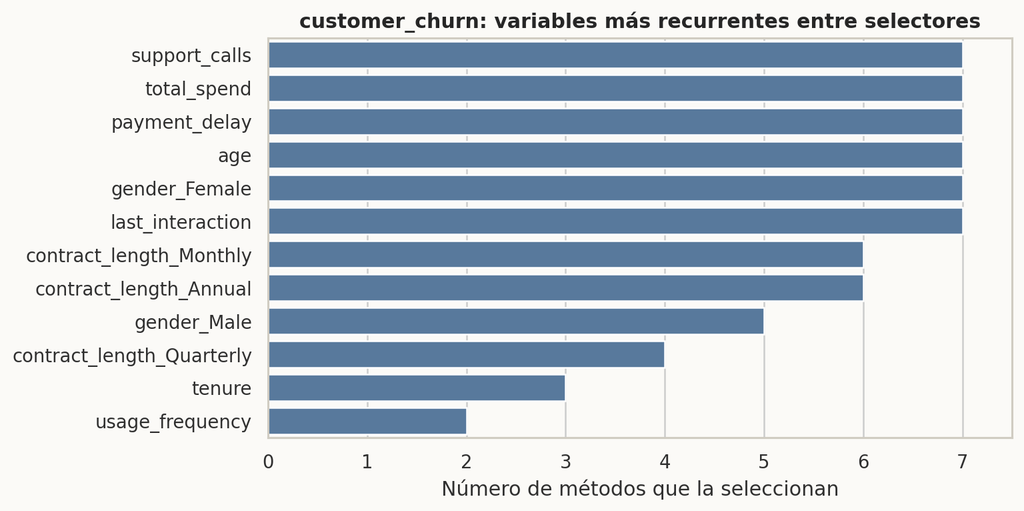

**Variables recurrentes en madelon**

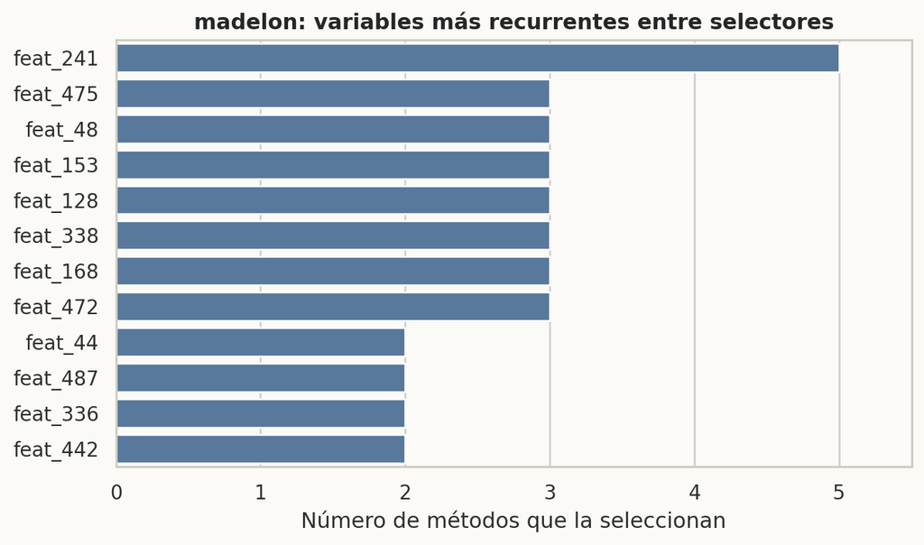

**Variables recurrentes en olive_oil_3class**

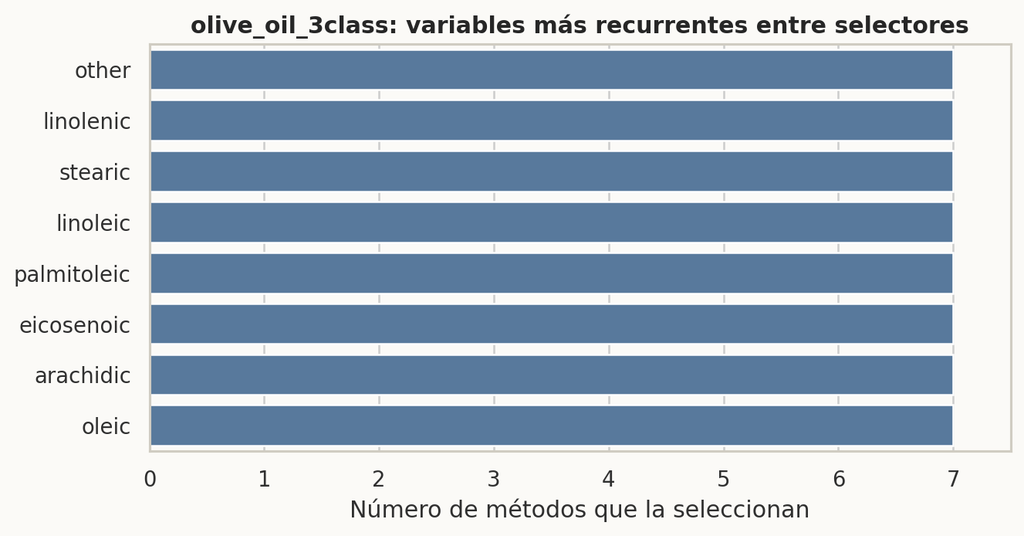

**Variables recurrentes en olive_oil_9class**

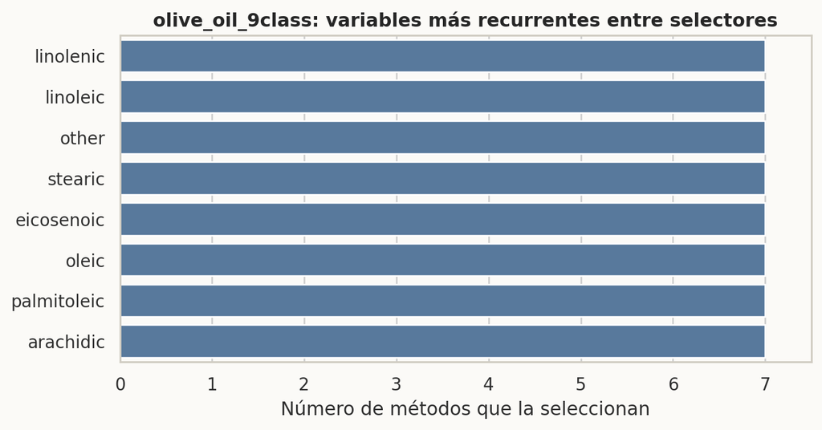

```python
for dataset in dataset_summary["dataset"]:
    ruta = f"results/figures/05_feature_selection/top_features/{dataset}_top_selected_features.png"
    mostrar_figura(ruta, f"Variables recurrentes en {dataset}")
```

## 5.9 Guardado tidy de rankings, subconjuntos y tiempos

```
        **Pregunta.** ¿Los resultados son trazables sin convertir el notebook en un inventario gigante?

        **Criterio metodológico.** El detalle completo permanece en CSV largos (`fs_all_rankings.csv`, `fs_all_selected_features.csv`, `fs_all_execution_times.csv`). El notebook solo muestra perfiles que ayudan a interpretar.
```

```python
trazabilidad = pd.DataFrame(
    [
        {"artefacto": "fs_all_rankings.csv", "filas": len(artefactos["fs_all_rankings.csv"]), "uso": "ranking largo por dataset, método, seed, k y variable"},
        {"artefacto": "fs_all_selected_features.csv", "filas": len(artefactos["fs_all_selected_features.csv"]), "uso": "subconjuntos seleccionados en formato trazable"},
        {"artefacto": "fs_all_execution_times.csv", "filas": len(artefactos["fs_all_execution_times.csv"]), "uso": "tiempos, muestra y estado por ejecución"},
        {"artefacto": "fs_phase6_input_recommendations.csv", "filas": len(phase6_recommendations), "uso": "entradas principales y auxiliares para Fase 6"},
    ]
)
mostrar_tabla_compacta(trazabilidad, "Artefactos largos preservados fuera del notebook", max_filas=8)
```

**Artefactos largos preservados fuera del notebook**  
4 filas completas en CSV; se muestra una vista compacta de 4 filas.

|  | artefacto | filas | uso |
| --- | --- | --- | --- |
| 0 | fs_all_rankings.csv | 79863 | ranking largo por dataset, método, seed, k y v... |
| 1 | fs_all_selected_features.csv | 6342 | subconjuntos seleccionados en formato trazable |
| 2 | fs_all_execution_times.csv | 105 | tiempos, muestra y estado por ejecución |
| 3 | fs_phase6_input_recommendations.csv | 168 | entradas principales y auxiliares para Fase 6 |

|  | artefacto | filas | uso |
| --- | --- | --- | --- |
| 0 | fs_all_rankings.csv | 79863 | ranking largo por dataset, método, seed, k y v... |
| 1 | fs_all_selected_features.csv | 6342 | subconjuntos seleccionados en formato trazable |
| 2 | fs_all_execution_times.csv | 105 | tiempos, muestra y estado por ejecución |
| 3 | fs_phase6_input_recommendations.csv | 168 | entradas principales y auxiliares para Fase 6 |

**Decisión.** No se muestran tablas largas de rankings en el notebook porque inducen lectura mecánica y duplican CSV. La evidencia completa queda guardada y recargable.

## 5.10 Estabilidad por semillas

```
        **Pregunta.** ¿La selección depende de la semilla?

        **Criterio metodológico.** Jaccard mide solapamiento de subconjuntos; Kuncheva corrige el solapamiento esperado por azar. Baja estabilidad no descarta utilidad: puede indicar variables redundantes o soluciones alternativas.
```

```python
stability_dataset = (
    method_dataset_profile.groupby("dataset", as_index=False)
    .agg(mean_jaccard=("mean_jaccard", "mean"), min_jaccard=("mean_jaccard", "min"))
)
mostrar_tabla_compacta(stability_dataset, "Estabilidad media por dataset", max_filas=8, formato={"mean_jaccard": numero, "min_jaccard": numero})
mostrar_tabla_compacta(
    method_dataset_profile,
    "Métodos menos estables que conviene vigilar",
    columnas=["dataset", "method", "mean_jaccard", "mean_selected_corr"],
    ordenar_por="mean_jaccard",
    max_filas=12,
    formato={"mean_jaccard": numero, "mean_selected_corr": numero},
)
```

**Estabilidad media por dataset**  
5 filas completas en CSV; se muestra una vista compacta de 5 filas.

|  | dataset | mean_jaccard | min_jaccard |
| --- | --- | --- | --- |
| 0 | breast_cancer_wisconsin | 0.979 | 0.852 |
| 1 | customer_churn | 0.920 | 0.742 |
| 2 | madelon | 0.703 | 0.111 |
| 3 | olive_oil_3class | 1.000 | 1.000 |
| 4 | olive_oil_9class | 0.979 | 0.926 |

**Métodos menos estables que conviene vigilar**  
35 filas completas en CSV; se muestra una vista compacta de 12 filas.

|  | dataset | method | mean_jaccard | mean_selected_corr |
| --- | --- | --- | --- | --- |
| 17 | madelon | mrmr_approx | 0.111 | 0.017 |
| 18 | madelon | mutual_info | 0.127 | 0.053 |
| 19 | madelon | random_forest | 0.681 | 0.306 |
| 11 | customer_churn | mutual_info | 0.742 | 0.096 |
| 10 | customer_churn | mrmr_approx | 0.756 | 0.075 |
| 5 | breast_cancer_wisconsin | random_forest | 0.852 | 0.681 |
| 33 | olive_oil_9class | random_forest | 0.926 | 0.461 |
| 31 | olive_oil_9class | mrmr_approx | 0.926 | 0.332 |
| 8 | customer_churn | l1_logistic | 0.964 | 0.088 |
| 9 | customer_churn | linear_svm | 0.976 | 0.142 |
| 28 | olive_oil_9class | f_classif | 1.000 | 0.461 |
| 27 | olive_oil_3class | variance | 1.000 | 0.552 |

|  | dataset | method | mean_jaccard | mean_selected_corr |
| --- | --- | --- | --- | --- |
| 17 | madelon | mrmr_approx | 0.111 | 0.017 |
| 18 | madelon | mutual_info | 0.127 | 0.053 |
| 19 | madelon | random_forest | 0.681 | 0.306 |
| 11 | customer_churn | mutual_info | 0.742 | 0.096 |
| 10 | customer_churn | mrmr_approx | 0.756 | 0.075 |
| 5 | breast_cancer_wisconsin | random_forest | 0.852 | 0.681 |
| 33 | olive_oil_9class | random_forest | 0.926 | 0.461 |
| 31 | olive_oil_9class | mrmr_approx | 0.926 | 0.332 |
| 8 | customer_churn | l1_logistic | 0.964 | 0.088 |
| 9 | customer_churn | linear_svm | 0.976 | 0.142 |
| 28 | olive_oil_9class | f_classif | 1.000 | 0.461 |
| 27 | olive_oil_3class | variance | 1.000 | 0.552 |

**Implicación para Fase 6.** Los métodos estables son candidatos naturales para la parrilla inicial. Los métodos menos estables pueden mantenerse como sensibilidad si el rendimiento de validación compensa esa incertidumbre.

## 5.11 Permutaciones del target

```
        **Pregunta.** ¿Los scores reales superan una referencia nula simple?

        **Criterio metodológico.** Se compara el score real con una distribución nula generada permutando `y_train`. Con 20 permutaciones, la evidencia es aproximada y sirve como diagnóstico, no como prueba definitiva.
```

**Resumen de variables por encima del p95 nulo**  
10 filas completas en CSV; se muestra una vista compacta de 10 filas.

|  | dataset | method | n_features_above_null | median_empirical_p_value | n_permutations |
| --- | --- | --- | --- | --- | --- |
| 0 | breast_cancer_wisconsin | f_classif | 26 | 0.048 | 20 |
| 1 | breast_cancer_wisconsin | mutual_info | 27 | 0.048 | 20 |
| 2 | customer_churn | f_classif | 15 | 0.048 | 20 |
| 3 | customer_churn | mutual_info | 9 | 0.048 | 20 |
| 4 | madelon | f_classif | 66 | 0.429 | 20 |
| 5 | madelon | mutual_info | 48 | 0.810 | 20 |
| 6 | olive_oil_3class | f_classif | 7 | 0.048 | 20 |
| 7 | olive_oil_3class | mutual_info | 8 | 0.048 | 20 |
| 8 | olive_oil_9class | f_classif | 8 | 0.048 | 20 |
| 9 | olive_oil_9class | mutual_info | 8 | 0.048 | 20 |

**Permutaciones: score real frente a nulo**

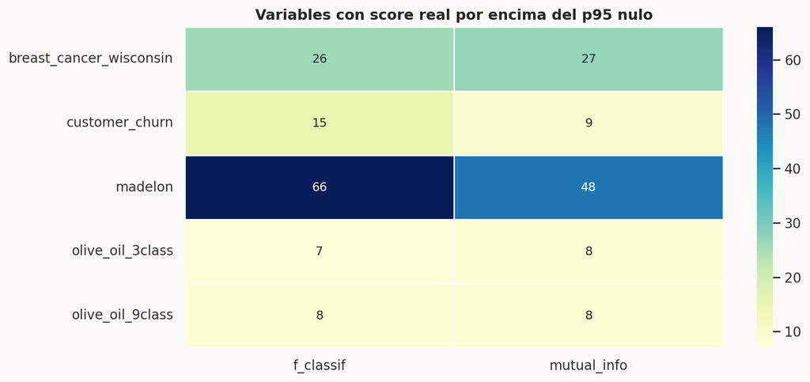

```python
mostrar_tabla_compacta(
    permutation,
    "Resumen de variables por encima del p95 nulo",
    columnas=["dataset", "method", "n_features_above_null", "median_empirical_p_value", "n_permutations"],
    max_filas=12,
    formato={"median_empirical_p_value": numero},
)
mostrar_figura("results/figures/05_feature_selection/permutation/fs_permutation_above_null_heatmap.png", "Permutaciones: score real frente a nulo")
```

## 5.12 Redundancia interna de subconjuntos

```
        **Pregunta.** ¿La selección reduce información repetida o conserva bloques redundantes?

        **Criterio metodológico.** Se compara correlación media/máxima de subconjuntos contra el conjunto completo. La redundancia no es siempre mala, pero puede inflar interpretaciones de importancia.
```

```python
redundancy_principal = principal_phase6.merge(
    redundancy,
    on=["dataset", "method", "k"],
    how="left",
)
mostrar_tabla_compacta(
    redundancy_principal,
    "Redundancia en subconjuntos principales para Fase 6",
    columnas=["dataset", "method", "k", "selected_mean_abs_corr", "selected_max_abs_corr", "selected_high_corr_pairs", "full_high_corr_pairs"],
    ordenar_por="selected_mean_abs_corr",
    ascendente=False,
    max_filas=20,
    formato={"selected_mean_abs_corr": numero, "selected_max_abs_corr": numero},
)
```

**Redundancia en subconjuntos principales para Fase 6**  
20 filas completas en CSV; se muestra una vista compacta de 20 filas.

|  | dataset | method | k | selected_mean_abs_corr | selected_max_abs_corr | selected_high_corr_pairs | full_high_corr_pairs |
| --- | --- | --- | --- | --- | --- | --- | --- |
| 3 | breast_cancer_wisconsin | random_forest | 10 | 0.819 | 1.000 | 18 | 29 |
| 2 | breast_cancer_wisconsin | mutual_info | 10 | 0.819 | 1.000 | 18 | 29 |
| 0 | breast_cancer_wisconsin | f_classif | 10 | 0.817 | 1.000 | 20 | 29 |
| 11 | madelon | random_forest | 10 | 0.435 | 0.996 | 3 | 12 |
| 1 | breast_cancer_wisconsin | mrmr_approx | 10 | 0.424 | 0.999 | 4 | 29 |
| 8 | madelon | f_classif | 10 | 0.385 | 0.996 | 4 | 12 |
| 16 | olive_oil_9class | f_classif | 8 | 0.330 | 0.860 | 1 | 1 |
| 18 | olive_oil_9class | mutual_info | 8 | 0.330 | 0.860 | 1 | 1 |
| 17 | olive_oil_9class | mrmr_approx | 8 | 0.330 | 0.860 | 1 | 1 |
| 19 | olive_oil_9class | random_forest | 8 | 0.330 | 0.860 | 1 | 1 |
| 13 | olive_oil_3class | mrmr_approx | 8 | 0.319 | 0.865 | 1 | 1 |
| 14 | olive_oil_3class | mutual_info | 8 | 0.319 | 0.865 | 1 | 1 |
| 12 | olive_oil_3class | f_classif | 8 | 0.319 | 0.865 | 1 | 1 |
| 15 | olive_oil_3class | random_forest | 8 | 0.319 | 0.865 | 1 | 1 |
| 7 | customer_churn | random_forest | 10 | 0.122 | 1.000 | 1 | 1 |
| 6 | customer_churn | mutual_info | 10 | 0.122 | 1.000 | 1 | 1 |
| 4 | customer_churn | f_classif | 10 | 0.122 | 1.000 | 1 | 1 |
| 10 | madelon | mutual_info | 10 | 0.072 | 0.685 | 0 | 12 |
| 5 | customer_churn | mrmr_approx | 10 | 0.050 | 0.218 | 0 | 1 |
| 9 | madelon | mrmr_approx | 10 | 0.016 | 0.049 | 0 | 12 |

|  | dataset | method | k | selected_mean_abs_corr | selected_max_abs_corr | selected_high_corr_pairs | full_high_corr_pairs |
| --- | --- | --- | --- | --- | --- | --- | --- |
| 3 | breast_cancer_wisconsin | random_forest | 10 | 0.819 | 1.000 | 18 | 29 |
| 2 | breast_cancer_wisconsin | mutual_info | 10 | 0.819 | 1.000 | 18 | 29 |
| 0 | breast_cancer_wisconsin | f_classif | 10 | 0.817 | 1.000 | 20 | 29 |
| 11 | madelon | random_forest | 10 | 0.435 | 0.996 | 3 | 12 |
| 1 | breast_cancer_wisconsin | mrmr_approx | 10 | 0.424 | 0.999 | 4 | 29 |
| 8 | madelon | f_classif | 10 | 0.385 | 0.996 | 4 | 12 |
| 16 | olive_oil_9class | f_classif | 8 | 0.330 | 0.860 | 1 | 1 |
| 18 | olive_oil_9class | mutual_info | 8 | 0.330 | 0.860 | 1 | 1 |
| 17 | olive_oil_9class | mrmr_approx | 8 | 0.330 | 0.860 | 1 | 1 |
| 19 | olive_oil_9class | random_forest | 8 | 0.330 | 0.860 | 1 | 1 |
| 13 | olive_oil_3class | mrmr_approx | 8 | 0.319 | 0.865 | 1 | 1 |
| 14 | olive_oil_3class | mutual_info | 8 | 0.319 | 0.865 | 1 | 1 |
| 12 | olive_oil_3class | f_classif | 8 | 0.319 | 0.865 | 1 | 1 |
| 15 | olive_oil_3class | random_forest | 8 | 0.319 | 0.865 | 1 | 1 |
| 7 | customer_churn | random_forest | 10 | 0.122 | 1.000 | 1 | 1 |
| 6 | customer_churn | mutual_info | 10 | 0.122 | 1.000 | 1 | 1 |
| 4 | customer_churn | f_classif | 10 | 0.122 | 1.000 | 1 | 1 |
| 10 | madelon | mutual_info | 10 | 0.072 | 0.685 | 0 | 12 |
| 5 | customer_churn | mrmr_approx | 10 | 0.050 | 0.218 | 0 | 1 |
| 9 | madelon | mrmr_approx | 10 | 0.016 | 0.049 | 0 | 12 |

**Riesgo residual.** Si un subconjunto tiene alta correlación interna, Fase 6 debe valorar si el rendimiento justifica esa redundancia o si conviene preferir métodos de relevancia-redundancia.

## 5.13 Cruce con EDA y señales sospechosas

```
        **Pregunta.** ¿La selección contradice o complementa la evidencia estadística previa?

        **Criterio metodológico.** Una variable sin señal univariante previa puede ser útil multivariadamente; por tanto, el cruce con EDA informa riesgos, no borra variables automáticamente.
```

```python
evidence = evidence_map.copy()
coverage_dataset = evidence.groupby("dataset", as_index=False).agg(mean_evidence_coverage=("evidence_coverage", "mean"), max_evidence_coverage=("evidence_coverage", "max"))
mostrar_tabla_compacta(coverage_dataset, "Cobertura media de evidencia previa por dataset", max_filas=8, formato={"mean_evidence_coverage": porcentaje, "max_evidence_coverage": porcentaje})
display(Markdown(f"**Variables sospechosas seleccionadas:** {len(artefactos['fs_suspicious_selected_features.csv'])}."))
```

**Cobertura media de evidencia previa por dataset**  
5 filas completas en CSV; se muestra una vista compacta de 5 filas.

[output not shown]

**Variables sospechosas seleccionadas:** 0.

**Interpretación.** El cruce con EDA no encuentra variables sospechosas seleccionadas. La baja cobertura de evidencia previa en algunos subconjuntos se interpreta con cautela: puede reflejar señal multivariante o limitaciones del mapeo entre nombres transformados y evidencia de fases tempranas.

## 5.14 Datasets reducidos para Fase 6

```
        **Pregunta.** ¿Qué debe consumir Fase 6 y qué queda como material auxiliar?

        **Criterio metodológico.** Los directorios `principal_para_modelado` forman una parrilla inicial compacta. El resto de subconjuntos se conserva para sensibilidad, ablación o apéndice; no se reajustan selectores en Fase 6.
```

```python
mostrar_tabla_compacta(
    principal_profile,
    "Subconjuntos principales recomendados para Fase 6",
    columnas=["dataset", "method", "k", "path", "mean_jaccard", "mean_selected_corr", "riesgo_residual"],
    max_filas=25,
    formato={"mean_jaccard": numero, "mean_selected_corr": numero},
)
consistency = artefactos["fs_column_consistency_check.csv"]
consistency_summary = consistency.groupby("dataset", as_index=False).agg(all_columns_exist=("all_columns_exist", "all"), same_order=("same_order_train_validation_test", "all"), no_extra_columns=("no_extra_columns", "all"))
mostrar_tabla_compacta(consistency_summary, "Consistencia de columnas en datasets reducidos", max_filas=8)
```

**Subconjuntos principales recomendados para Fase 6**  
20 filas completas en CSV; se muestra una vista compacta de 20 filas.

|  | dataset | method | k | path | mean_jaccard | mean_selected_corr | riesgo_residual |
| --- | --- | --- | --- | --- | --- | --- | --- |
| 0 | breast_cancer_wisconsin | f_classif | 10 | data/selected_features/breast_cancer_wisconsin... | 1.000 | 0.696 | validar rendimiento en Fase 6 sin reajustar se... |
| 1 | breast_cancer_wisconsin | mrmr_approx | 10 | data/selected_features/breast_cancer_wisconsin... | 1.000 | 0.372 | validar rendimiento en Fase 6 sin reajustar se... |
| 2 | breast_cancer_wisconsin | mutual_info | 10 | data/selected_features/breast_cancer_wisconsin... | 1.000 | 0.700 | validar rendimiento en Fase 6 sin reajustar se... |
| 3 | breast_cancer_wisconsin | random_forest | 10 | data/selected_features/breast_cancer_wisconsin... | 0.852 | 0.681 | validar rendimiento en Fase 6 sin reajustar se... |
| 4 | customer_churn | f_classif | 10 | data/selected_features/customer_churn/f_classi... | 1.000 | 0.096 | validar rendimiento en Fase 6 sin reajustar se... |
| 5 | customer_churn | mrmr_approx | 10 | data/selected_features/customer_churn/mrmr_app... | 0.756 | 0.075 | validar rendimiento en Fase 6 sin reajustar se... |
| 6 | customer_churn | mutual_info | 10 | data/selected_features/customer_churn/mutual_i... | 0.742 | 0.096 | validar rendimiento en Fase 6 sin reajustar se... |
| 7 | customer_churn | random_forest | 10 | data/selected_features/customer_churn/random_f... | 1.000 | 0.089 | validar rendimiento en Fase 6 sin reajustar se... |
| 8 | madelon | f_classif | 10 | data/selected_features/madelon/f_classif/k_10/ | 1.000 | 0.244 | validar rendimiento en Fase 6 sin reajustar se... |
| 9 | madelon | mrmr_approx | 10 | data/selected_features/madelon/mrmr_approx/k_10/ | 0.111 | 0.017 | validar rendimiento en Fase 6 sin reajustar se... |
| 10 | madelon | mutual_info | 10 | data/selected_features/madelon/mutual_info/k_10/ | 0.127 | 0.053 | validar rendimiento en Fase 6 sin reajustar se... |
| 11 | madelon | random_forest | 10 | data/selected_features/madelon/random_forest/k... | 0.681 | 0.306 | validar rendimiento en Fase 6 sin reajustar se... |
| 12 | olive_oil_3class | f_classif | 8 | data/selected_features/olive_oil_3class/f_clas... | 1.000 | 0.493 | validar rendimiento en Fase 6 sin reajustar se... |
| 13 | olive_oil_3class | mrmr_approx | 8 | data/selected_features/olive_oil_3class/mrmr_a... | 1.000 | 0.218 | validar rendimiento en Fase 6 sin reajustar se... |
| 14 | olive_oil_3class | mutual_info | 8 | data/selected_features/olive_oil_3class/mutual... | 1.000 | 0.457 | validar rendimiento en Fase 6 sin reajustar se... |
| 15 | olive_oil_3class | random_forest | 8 | data/selected_features/olive_oil_3class/random... | 1.000 | 0.448 | validar rendimiento en Fase 6 sin reajustar se... |
| 16 | olive_oil_9class | f_classif | 8 | data/selected_features/olive_oil_9class/f_clas... | 1.000 | 0.461 | validar rendimiento en Fase 6 sin reajustar se... |
| 17 | olive_oil_9class | mrmr_approx | 8 | data/selected_features/olive_oil_9class/mrmr_a... | 0.926 | 0.332 | validar rendimiento en Fase 6 sin reajustar se... |
| 18 | olive_oil_9class | mutual_info | 8 | data/selected_features/olive_oil_9class/mutual... | 1.000 | 0.564 | validar rendimiento en Fase 6 sin reajustar se... |
| 19 | olive_oil_9class | random_forest | 8 | data/selected_features/olive_oil_9class/random... | 0.926 | 0.461 | validar rendimiento en Fase 6 sin reajustar se... |

**Consistencia de columnas en datasets reducidos**  
5 filas completas en CSV; se muestra una vista compacta de 5 filas.

|  | dataset | all_columns_exist | same_order | no_extra_columns |
| --- | --- | --- | --- | --- |
| 0 | breast_cancer_wisconsin | True | True | True |
| 1 | customer_churn | True | True | True |
| 2 | madelon | True | True | True |
| 3 | olive_oil_3class | True | True | True |
| 4 | olive_oil_9class | True | True | True |

|  | dataset | all_columns_exist | same_order | no_extra_columns |
| --- | --- | --- | --- | --- |
| 0 | breast_cancer_wisconsin | True | True | True |
| 1 | customer_churn | True | True | True |
| 2 | madelon | True | True | True |
| 3 | olive_oil_3class | True | True | True |
| 4 | olive_oil_9class | True | True | True |

**Decisión.** Fase 6 debe partir de `fs_phase6_input_recommendations.csv`: cuatro métodos principales por dataset para una primera comparación, manteniendo todos los artefactos auxiliares disponibles sin mezclarlos con la parrilla principal.

## 5.15 Comparación narrativa y visual

```
        **Pregunta.** ¿Qué métodos parecen más útiles por dataset antes de modelar?

        **Criterio metodológico.** La utilidad se lee como equilibrio entre coste, estabilidad, redundancia y evidencia nula, no como rendimiento predictivo final. El rendimiento se decide en Fase 6.
```

**Lectura de métodos principales por dataset**  
20 filas completas en CSV; se muestra una vista compacta de 20 filas.

|  | dataset | method | k | mean_jaccard | mean_selected_corr | lectura | cautela_redundancia |
| --- | --- | --- | --- | --- | --- | --- | --- |
| 0 | breast_cancer_wisconsin | f_classif | 10 | 1.000 | 0.696 | estable entre semillas | vigilar redundancia |
| 1 | breast_cancer_wisconsin | mrmr_approx | 10 | 1.000 | 0.372 | estable entre semillas | redundancia contenida |
| 2 | breast_cancer_wisconsin | mutual_info | 10 | 1.000 | 0.700 | estable entre semillas | vigilar redundancia |
| 3 | breast_cancer_wisconsin | random_forest | 10 | 0.852 | 0.681 | estable entre semillas | vigilar redundancia |
| 4 | customer_churn | f_classif | 10 | 1.000 | 0.096 | estable entre semillas | redundancia contenida |
| 5 | customer_churn | mrmr_approx | 10 | 0.756 | 0.075 | sensible a semilla o alternativas equivalentes | redundancia contenida |
| 6 | customer_churn | mutual_info | 10 | 0.742 | 0.096 | sensible a semilla o alternativas equivalentes | redundancia contenida |
| 7 | customer_churn | random_forest | 10 | 1.000 | 0.089 | estable entre semillas | redundancia contenida |
| 8 | madelon | f_classif | 10 | 1.000 | 0.244 | estable entre semillas | redundancia contenida |
| 9 | madelon | mrmr_approx | 10 | 0.111 | 0.017 | sensible a semilla o alternativas equivalentes | redundancia contenida |
| 10 | madelon | mutual_info | 10 | 0.127 | 0.053 | sensible a semilla o alternativas equivalentes | redundancia contenida |
| 11 | madelon | random_forest | 10 | 0.681 | 0.306 | sensible a semilla o alternativas equivalentes | redundancia contenida |
| 12 | olive_oil_3class | f_classif | 8 | 1.000 | 0.493 | estable entre semillas | redundancia contenida |
| 13 | olive_oil_3class | mrmr_approx | 8 | 1.000 | 0.218 | estable entre semillas | redundancia contenida |
| 14 | olive_oil_3class | mutual_info | 8 | 1.000 | 0.457 | estable entre semillas | redundancia contenida |
| 15 | olive_oil_3class | random_forest | 8 | 1.000 | 0.448 | estable entre semillas | redundancia contenida |
| 16 | olive_oil_9class | f_classif | 8 | 1.000 | 0.461 | estable entre semillas | redundancia contenida |
| 17 | olive_oil_9class | mrmr_approx | 8 | 0.926 | 0.332 | estable entre semillas | redundancia contenida |
| 18 | olive_oil_9class | mutual_info | 8 | 1.000 | 0.564 | estable entre semillas | vigilar redundancia |
| 19 | olive_oil_9class | random_forest | 8 | 0.926 | 0.461 | estable entre semillas | redundancia contenida |

**Perfil global de métodos: coste, estabilidad y redundancia**

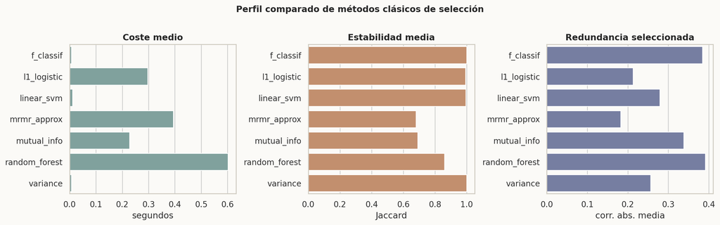

**Coincidencia método-variable en breast_cancer_wisconsin**

[figure not shown]

**Coincidencia método-variable en customer_churn**

[figure not shown]

**Coincidencia método-variable en madelon**

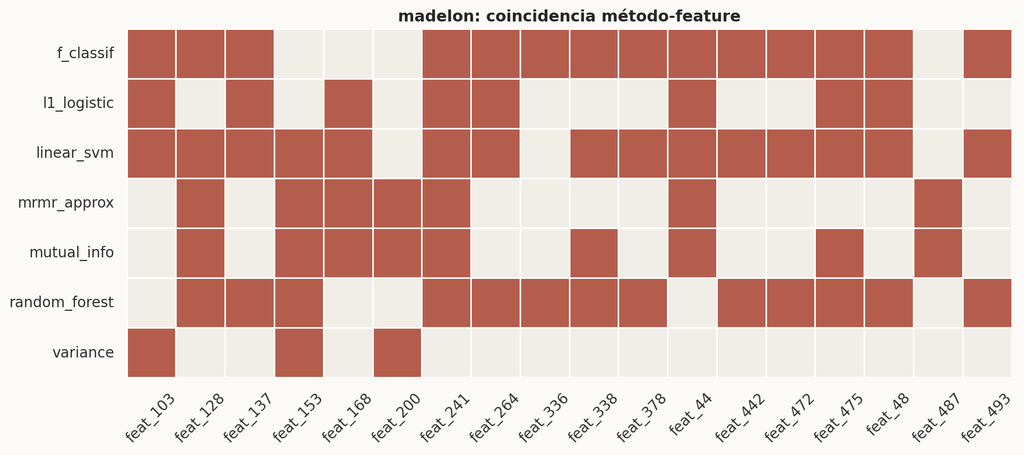

**Coincidencia método-variable en olive_oil_3class**

[figure not shown]

**Coincidencia método-variable en olive_oil_9class**

[figure not shown]

**Lámina de revisión visual de candidatas para memoria**

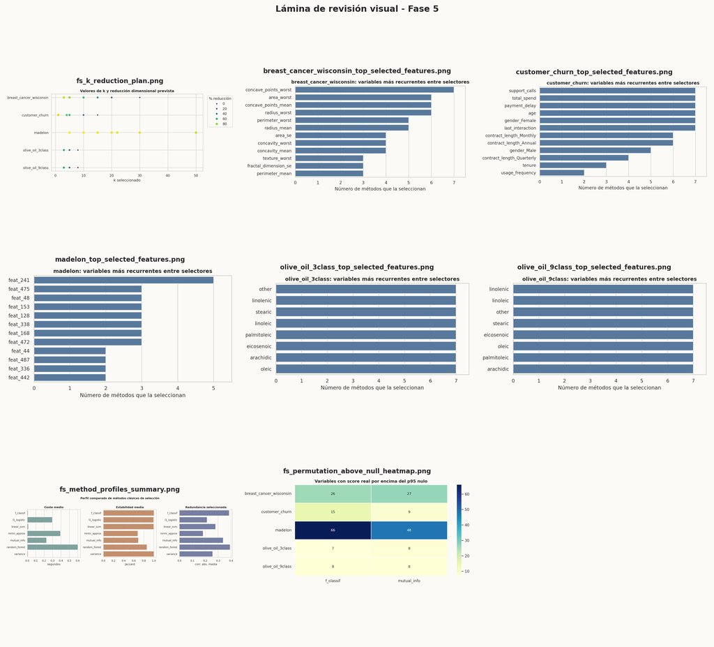

```python
mostrar_tabla_compacta(
    dataset_method_reading,
    "Lectura de métodos principales por dataset",
    columnas=["dataset", "method", "k", "mean_jaccard", "mean_selected_corr", "lectura", "cautela_redundancia"],
    max_filas=25,
    formato={"mean_jaccard": numero, "mean_selected_corr": numero},
)
mostrar_figura("results/figures/05_feature_selection/summary/fs_method_profiles_summary.png", "Perfil global de métodos: coste, estabilidad y redundancia")
for dataset in dataset_summary["dataset"]:
    ruta = f"results/figures/05_feature_selection/method_feature_heatmaps/{dataset}_method_feature_heatmap.png"
    mostrar_figura(ruta, f"Coincidencia método-variable en {dataset}")
mostrar_figura("results/figures/05_feature_selection/visual_review_sheet/fs_visual_review_sheet.png", "Lámina de revisión visual de candidatas para memoria")
```

**Lectura prudente.** `f_classif` y `mutual_info` son referencias fuertes por coste y señal marginal; `mrmr_approx` aporta control de redundancia con menor estabilidad; `random_forest` añade una lectura embedded útil, pero dependiente de modelo; `variance` queda como baseline no supervisada y no debe interpretarse como evidencia de relación con el target.

## 5.16 Cierre, checklist y handoff

```
        **Pregunta.** ¿La fase queda lista para modelado sin perder cautelas?

        **Criterio metodológico.** El cierre no elige modelos. Entrega subconjuntos, riesgos y una parrilla compacta para que Fase 6 evalúe rendimiento sin contaminar validation/test.
```

```python
mostrar_tabla_compacta(artefactos["fs_phase5_final_checklist.csv"], "Checklist final de Fase 5", max_filas=20)
mostrar_tabla_compacta(artefactos["fs_phase5_handoff_to_phase6.csv"], "Handoff resumido a Fase 6", max_filas=8)
mostrar_tabla_compacta(artefactos["fs_phase5_open_issues.csv"], "Incidencias y cautelas abiertas", max_filas=8)
```

**Checklist final de Fase 5**  
15 filas completas en CSV; se muestra una vista compacta de 15 filas.

|  | criterio | cumple | evidencia |
| --- | --- | --- | --- |
| 0 | splits cargados correctamente | True | fs_input_load_check.csv |
| 1 | selección ajustada solo con train | True | fs_experiment_log.csv |
| 2 | métodos registrados | True | fs_method_registry.csv |
| 3 | k definidos por dataset | True | fs_k_values_by_dataset.csv |
| 4 | muestreo documentado | True | fs_sampling_plan.csv |
| 5 | rankings y subconjuntos guardados | True | fs_all_rankings.csv |
| 6 | tiempos guardados | True | fs_all_execution_times.csv |
| 7 | estabilidad analizada | True | fs_jaccard_stability.csv |
| 8 | permutaciones ejecutadas | True | fs_permutation_summary.csv |
| 9 | redundancia medida | True | fs_redundancy_vs_full.csv |
| 10 | cruce con EDA generado | True | fs_selection_vs_eda_evidence.csv |
| 11 | datasets reducidos creados | True | fs_reduced_datasets_log.csv |
| 12 | figuras auditadas | True | fs_visual_audit.csv |
| 13 | informe trazable generado | True | fase5_feature_selection_report.md |
| 14 | handoff a Fase 6 creado | True | fs_phase5_handoff_to_phase6.csv |

**Handoff resumido a Fase 6**  
5 filas completas en CSV; se muestra una vista compacta de 5 filas.

|  | dataset | recomendacion_fase6 | artefacto | tabla_recomendaciones | riesgo_residual | estado |
| --- | --- | --- | --- | --- | --- | --- |
| 0 | breast_cancer_wisconsin | usar como entrada los directorios principal_pa... | data/selected_features/breast_cancer_wisconsin/ | fs_phase6_input_recommendations.csv | estabilidad/permutación deben considerarse jun... | listo_con_cautela |
| 1 | customer_churn | usar como entrada los directorios principal_pa... | data/selected_features/customer_churn/ | fs_phase6_input_recommendations.csv | estabilidad/permutación deben considerarse jun... | listo_con_cautela |
| 2 | madelon | usar como entrada los directorios principal_pa... | data/selected_features/madelon/ | fs_phase6_input_recommendations.csv | estabilidad/permutación deben considerarse jun... | listo_con_cautela |
| 3 | olive_oil_3class | usar como entrada los directorios principal_pa... | data/selected_features/olive_oil_3class/ | fs_phase6_input_recommendations.csv | estabilidad/permutación deben considerarse jun... | listo_con_cautela |
| 4 | olive_oil_9class | usar como entrada los directorios principal_pa... | data/selected_features/olive_oil_9class/ | fs_phase6_input_recommendations.csv | estabilidad/permutación deben considerarse jun... | listo_con_cautela |

**Incidencias y cautelas abiertas**  
3 filas completas en CSV; se muestra una vista compacta de 3 filas.

|  | dataset | issue | impact | status |
| --- | --- | --- | --- | --- |
| 0 | customer_churn | categoricas codificadas con one-hot fit solo e... | Fase 6 debe consumir columnas seleccionadas ya... | documentado |
| 1 | GLOBAL | artefactos auxiliares separados de entradas pr... | fs_phase6_input_recommendations.csv distingue ... | documentado |
| 2 | olive_oil_3class\|olive_oil_9class | formulaciones no intercambiables | no promediar ni reutilizar rankings entre targets | documentado |

|  | dataset | issue | impact | status |
| --- | --- | --- | --- | --- |
| 0 | customer_churn | categoricas codificadas con one-hot fit solo e... | Fase 6 debe consumir columnas seleccionadas ya... | documentado |
| 1 | GLOBAL | artefactos auxiliares separados de entradas pr... | fs_phase6_input_recommendations.csv distingue ... | documentado |
| 2 | olive_oil_3class\|olive_oil_9class | formulaciones no intercambiables | no promediar ni reutilizar rankings entre targets | documentado |

**Implicación final.** La Fase 5 queda como baseline clásica trazable. Fase 6 debe evaluar si la estabilidad y la reducción dimensional observadas se traducen en rendimiento robusto, manteniendo separadas las dos formulaciones de Olive Oil y tratando `customer_churn` con su cautela de codificación train-only.